# Tutorial 5: Preparing multi-national data

Forschungspraktikum I und II: Vergleichende Sozialforschung mit Mehrebenenmodellen in R

Dr. Christian Czymara (Sociology with Focus on Quantitative Methods for Social Research, Goethe University Frankfurt)

Can money buy happiness? This exercise will deal with life satisfaction and its connection to economic conditions on both the individual and the country level. This time we will first have to combine the data ourselves.

## 1. Importing data

Since we will work with two data sets, we have import both. First, import ESS8e02_1.dta and assign it to an object `ESS16`.

```r
setwd("C:/Users/czymara.local/Nextcloud/teaching/FoP HLM/_R/05_comparative_social_research")

library(haven)

ESS16 <- read_dta("ESS8e02_1.dta") # individual level data
```

## 2. Data inspection

### a) Income

The ESS uses special cards to measure income (`hinctnta`). The first one looks like this:

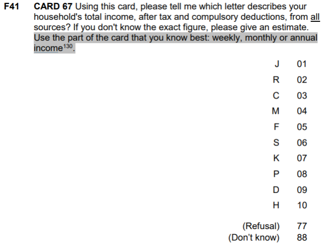

ESS income question card

Since the fourth round, the categories of the show cards are based on deciles of the actual household income range in each country (see [ESS documentation](https://www.europeansocialsurvey.org/docs/round4/survey/ESS4_appendix_a5_e05_0.pdf)). This has the huge benefit of better comparability across countries (100€ in Switzerland have different purchase power than 100€ in the Czech Republic). Keep this change in mind when comparing the variables `hinctnt` and `hinctnta` before and after wave 4, respectively.

The second card looks like this:

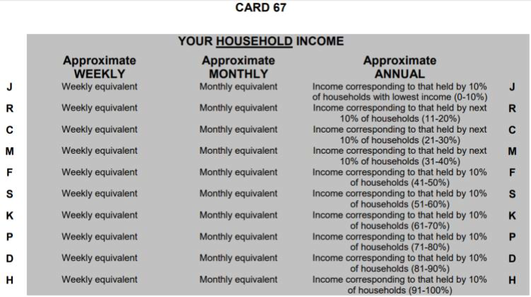

For example, the German questionnaire looks like this:

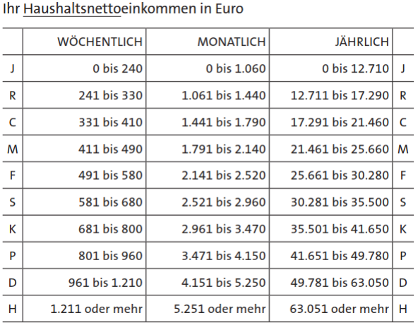

What is the distribution of the `hinctnta` variable?

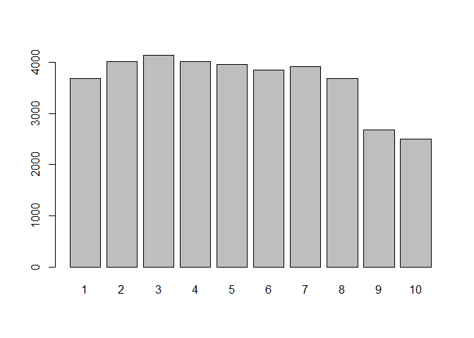

```r
barplot(table(ESS16$hinctnta))
```

### b) Life satisfaction & income

In total, how large is the correlation between life satisfaction and income?

```r
cor(ESS16$stflife, ESS16$hinctnta, use = "complete.obs")
```

```
## [1] 0.2338568
```

### c) Life satisfaction & income across countries

Have a look at the correlation between life satisfaction and income separately for each country. Does it vary?

```r
library(tidyverse)

ESS16 %>%
  group_by(cntry) %>%
  summarize(COR = cor(stflife, hinctnta, use = "complete.obs")) %>%
  arrange(desc(COR)) %>%
  print(n = Inf)
```

```
## # A tibble: 23 x 2
##    cntry   COR
##    <chr> <dbl>
##  1 EE    0.353
##  2 LT    0.336
##  3 SI    0.321
##  4 HU    0.300
##  5 FR    0.295
##  6 DE    0.289
##  7 FI    0.287
##  8 NL    0.282
##  9 IT    0.281
## 10 PT    0.274
## 11 IS    0.258
## 12 CZ    0.254
## 13 ES    0.215
## 14 SE    0.203
## 15 GB    0.202
## 16 PL    0.196
## 17 BE    0.188
## 18 IE    0.182
## 19 RU    0.169
## 20 AT    0.160
## 21 CH    0.151
## 22 NO    0.126
## 23 IL    0.104
```

## 3. Combining data

### a) Macro-level data

Let us add the country-level data. There are two sources: macrodata_1.xlsx and macrodata_2.csv. Import the XLSX using the `read_excel()` function of the `readxl` package and assign it to an object `macrodata_1`. Import the CSV and assign it to `macrodata_2`. Which countries are included in the ESS but *not* in macrodata_1 and *not* in macrodata_2, respectively?

```r
# install and load readxl
if(!require(readxl)){
    install.packages("readxl")
    library(readxl)
  }

macrodata_1 <- read_excel("macrodata_1.xlsx") # country level data 1

macrodata_2 <- read.csv2("macrodata_2.csv")  # country level data 2

setdiff(ESS16$cntry, macrodata_1$Country)
```

```
## [1] "RU"
```

```r
setdiff(ESS16$cntry, macrodata_2$Country)
```

```
## [1] "PL" "RU"
```

### b) Preparing country-level data

Mcrodata_1 includes the following information:

- GDP (gross domestic product) at current market prices - Purchasing Power Standards per inhabitant in percentage of the EU average 2016
- Gini coefficient of equalized disposable income 2016

How are these variables called in the data? Which variable will be the key variable for data merging? Make sure the key variable has the same name in all data sets (note that R is case sensitive).

```r
# inspect macro level data sets
head(macrodata_1)
```

```
## # A tibble: 6 x 3
##   Country c_pps_habeu_2016 c_gini_2016
##   <chr>              <dbl>       <dbl>
## 1 AT                   128        27.2
## 2 BE                   118        26.3
## 3 CH                    NA        29.4
## 4 CZ                    88        25.1
## 5 DE                   124        29.5
## 6 EE                    77        32.7
```

```r
head(macrodata_2)
```

```
##   Country c_soexgni_2015
## 1      AT          27.91
## 2      BE          29.25
## 3      CH          15.51
## 4      CZ          20.80
## 5      DE          24.41
## 6      EE          18.08
```

```r
# rename Cntry to cntry
colnames(macrodata_1)[1] <- "cntry"
colnames(macrodata_2)[1] <- "cntry"
```

### c) Joining data

Combine the ESS with both macro-level data sets using one of the `join` functions from the `dplyr` package.

```r
data_combined <- left_join(ESS16, macrodata_1, by = "cntry") %>%
  left_join(., macrodata_2, by = "cntry")

ncol(ESS16)
```

```
## [1] 534
```

```r
ncol(data_combined)
```

```
## [1] 537
```

```r
setdiff(ESS16$cntry, macrodata_2$cntry)
```

```
## [1] "PL" "RU"
```

```r
table(data_combined$cntry, is.na(data_combined$c_soexgni_2015)) # those countries who have missing values in the macro data are still included in the merged data set (left_join()), but with NA for these variables
```

```
##
##      FALSE TRUE
##   AT  2010    0
##   BE  1766    0
##   CH  1525    0
##   CZ  2269    0
##   DE  2852    0
##   EE  2019    0
##   ES  1958    0
##   FI  1925    0
##   FR  2070    0
##   GB  1959    0
##   HU  1614    0
##   IE  2757    0
##   IL  2557    0
##   IS   880    0
##   IT  2626    0
##   LT  2122    0
##   NL  1681    0
##   NO  1545    0
##   PL     0 1694
##   PT  1270    0
##   RU     0 2430
##   SE  1551    0
##   SI  1307    0
```

```r
# alternatively:
data_combined_alt <- inner_join(ESS16, macrodata_1, by = "cntry") %>%
  inner_join(., macrodata_2, by = "cntry")

table(data_combined_alt$cntry, is.na(data_combined_alt$c_soexgni_2015)) # now these countries are not included
```

```
##
##      FALSE
##   AT  2010
##   BE  1766
##   CH  1525
##   CZ  2269
##   DE  2852
##   EE  2019
##   ES  1958
##   FI  1925
##   FR  2070
##   GB  1959
##   HU  1614
##   IE  2757
##   IL  2557
##   IS   880
##   IT  2626
##   LT  2122
##   NL  1681
##   NO  1545
##   PT  1270
##   SE  1551
##   SI  1307
```

## 4. Country-level relationships

### a) Life satisfaction accross countries

What is the average life satisfaction of each country?

```r
data_combined %>%
  group_by(cntry) %>%
  summarize(mean = mean(stflife, na.rm=TRUE)) %>%
  arrange(desc(mean)) %>%
  print(n = Inf)
```

```
## # A tibble: 23 x 2
##    cntry  mean
##    <chr> <dbl>
##  1 CH     8.15
##  2 IS     8.03
##  3 FI     7.98
##  4 NO     7.94
##  5 SE     7.89
##  6 IL     7.79
##  7 NL     7.77
##  8 AT     7.66
##  9 DE     7.52
## 10 BE     7.48
## 11 GB     7.34
## 12 ES     7.30
## 13 IE     7.26
## 14 PL     7.16
## 15 SI     7.06
## 16 IT     6.82
## 17 EE     6.78
## 18 CZ     6.71
## 19 FR     6.54
## 20 HU     6.38
## 21 PT     6.26
## 22 LT     5.98
## 23 RU     5.67
```

### b) National economies and life satisfaction

Let’s see whether people are more unhappy in countries with a weaker economy and happier in countries with a strong welfare state. What is the correlation between life satisfaction and the three macro-level economic indicators?

```r
# GDP
data_combined %>%
  group_by(cntry) %>%
  summarize(mean = mean(stflife, na.rm=TRUE),
            c_pps_habeu_2016 = mean(c_pps_habeu_2016)) %>%
  summarize(COR = cor(mean, c_pps_habeu_2016, use = "complete.obs"))
```

```
## # A tibble: 1 x 1
##     COR
##   <dbl>
## 1 0.655
```

```r
# Gini
data_combined %>%
  group_by(cntry) %>%
  summarize(mean = mean(stflife, na.rm=TRUE),
            c_gini_2016 = mean(c_gini_2016)) %>%
  summarize(COR = cor(mean, c_gini_2016, use = "complete.obs"))
```

```
## # A tibble: 1 x 1
##      COR
##    <dbl>
## 1 -0.581
```

```r
# Social expenditure
data_combined %>%
  group_by(cntry) %>%
  summarize(mean = mean(stflife, na.rm=TRUE),
            c_soexgni_2015 = mean(c_soexgni_2015)) %>%
  summarize(COR = cor(mean, c_soexgni_2015, use = "complete.obs"))
```

```
## # A tibble: 1 x 1
##       COR
##     <dbl>
## 1 -0.0805
```

### c) Plotting

For each macro-variable, create a scatter plot with average life satisfaction on the y-axis and the economic indicator on the x-axis (use `ggplot2()`).

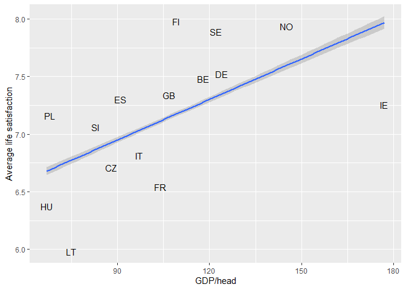

```r
# GDP
data_combined %>%
  ggplot(aes(x = c_pps_habeu_2016,
             y = stflife,
             label = cntry)) +
  stat_summary(fun = mean,
               geom = "text") +
  geom_smooth(method = "lm") +
  ylab("Average life satisfaction") +
  xlab("GDP/head")
```

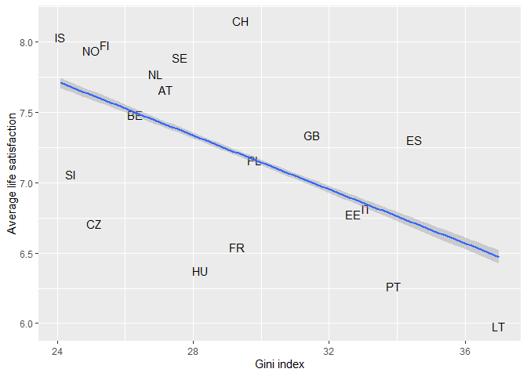

```r
# Gini
data_combined %>%
  ggplot(aes(x = c_gini_2016,
             y = stflife,
             label = cntry)) +
  stat_summary(fun = mean,
               geom = "text") +
  geom_smooth(method = "lm") +
  ylab("Average life satisfaction") +
  xlab("Gini index")
```

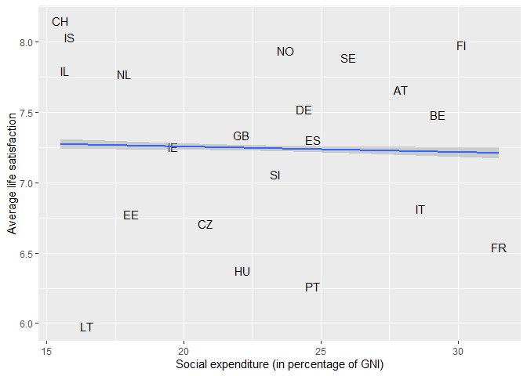

```r
# Social expenditure
data_combined %>%
  ggplot(aes(x = c_soexgni_2015,
             y = stflife,
             label = cntry)) +
  stat_summary(fun = mean,
               geom = "text") +
  geom_smooth(method = "lm") +
  ylab("Average life satisfaction") +
  xlab("Social expenditure (in percentage of GNI)")
```